# Week 11- Day 2

Decision trees homework

In this homework we will create a decision tree to see which factors are useful in predicting whether or not a passenger on the titanic will survive.

Run the code below before you begin:

```r
library(rpart)
library(rpart.plot)
library(tidyverse)

library(tidyverse)
titanic_set <- read_csv(here::here("titanic_decision_tree_data.csv"))
shuffle_index <- sample(1:nrow(titanic_set))

# shuffle the data so class order isn't in order - need this for training/testing split later on
titanic_set <- titanic_set[shuffle_index, ]
```

Data Dictionary

sex: Biological Sex, male or female age_status: adult or child (child defined as under 16) class : Ticket class, 1 = 1st (Upper class), 2 = 2nd (Middle Class), 3 = 3rd (Lower Class) port_embarkation: C = Cherbourg, Q = Queenstown, S = Southampton sibsp : number of siblings / spouses aboard the Titanic parch: number of parents / children aboard the Titanic. Some children travelled only with a nanny, therefore parch=0 for them. survived_flag : did they survive, 0 = No, 1 = Yes

#1 MVP #1.1 Question 1

Cleaning up the data is always the first step. Do the following:

Take only observations which have a survived flag (i.e. that aren’t missing) Turn your important variables into factors (sex, survived, pclass, embarkation) Create an age_status variable which groups individuals under (and including) 16 years of age into a category called “child” category and those over 16 into a category called “adult”. Drop the NA Drop any variables you don’t need (X1, passenger_id, name, ticket, far, cabin) If you need help doing this, the code is below, but please try it yourself first so you can learn!

## Thoughts

Do the above…

## Code

| sex | age_status | class | port_embarkation | sib_sp | parch | survived_flag |
| --- | --- | --- | --- | --- | --- | --- |
| female | adult | Lower | Southampton | 1 | 0 | No |
| female | adult | Lower | Southampton | 0 | 1 | Yes |
| female | child | Lower | Southampton | 4 | 2 | No |
| male | adult | Lower | Southampton | 0 | 0 | Yes |
| male | adult | Lower | Southampton | 0 | 0 | No |
| male | adult | Lower | Cherbourg | 0 | 0 | No |
| male | adult | Lower | Southampton | 0 | 0 | No |
| female | adult | Upper | Cherbourg | 1 | 0 | Yes |
| female | adult | Upper | Southampton | 0 | 0 | Yes |
| male | adult | Lower | Southampton | 2 | 0 | No |

[output cut: 702 more lines]

#1.2 Question 2

Have a look at your data and create some plots to ensure you know what you’re working with before you begin. Write a summary of what you have found in your plots. Which variables do you think might be useful to predict whether or not people are going to die? Knowing this before you start is the best way to have a sanity check that your model is doing a good job.

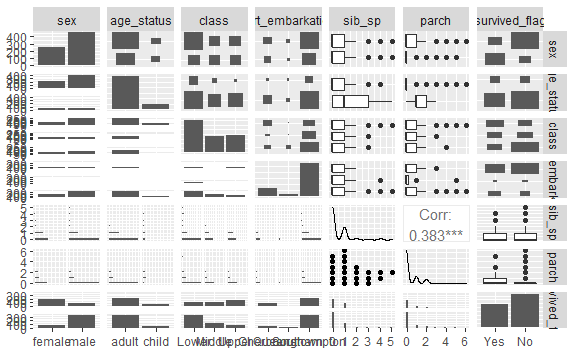

```r
library(GGally)
titanic_clean %>%
  ggpairs()
```

[figure not shown]

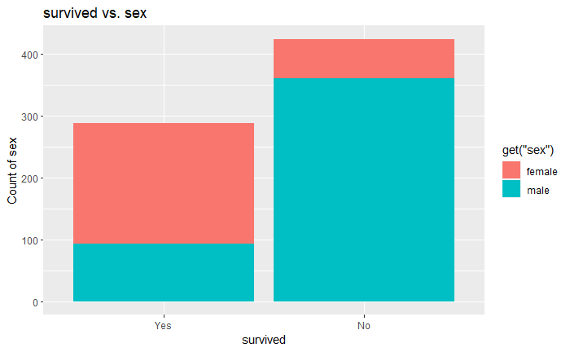

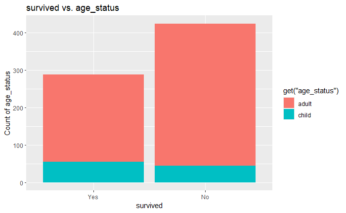

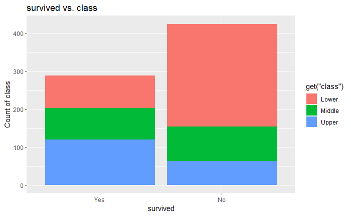

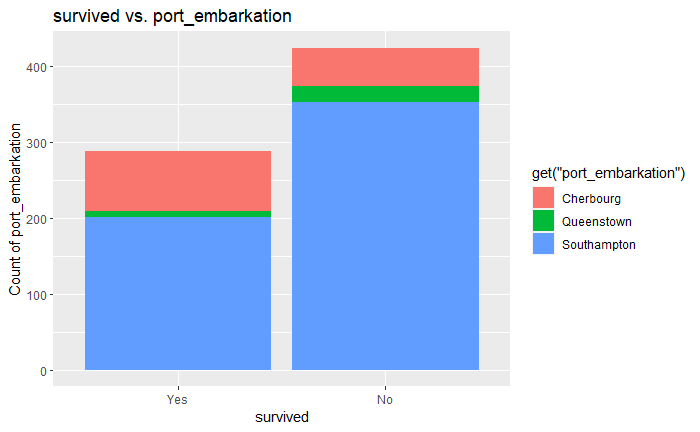

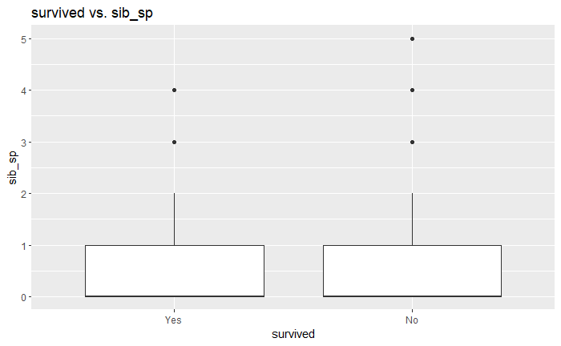

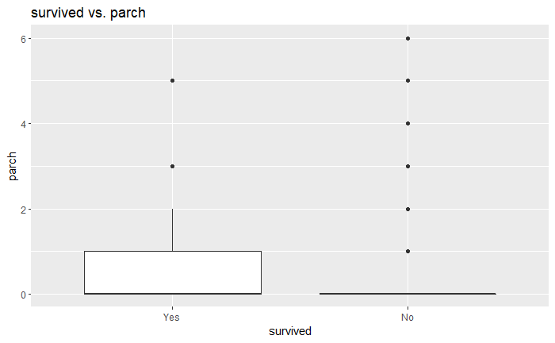

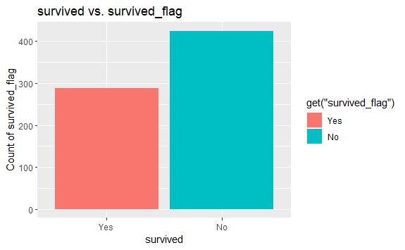

```r
for(i in 1:length(names(titanic_clean))){
  if(is.numeric(titanic_clean[[i]])){
    a <- titanic_clean %>%
      ggplot(aes(x = survived_flag,
                 y = get(!!names(.)[[i]]))) +
      geom_boxplot()+
      labs(x = "survived",
           y = names(titanic_clean)[i],
           title = paste("survived vs.", names(titanic_clean)[i]))
    print(a)
  }else{
    a <- titanic_clean %>%
      ggplot(aes(x = survived_flag,
                 fill = get(!!names(.)[[i]]))) +
      geom_bar()+
      labs(x = "survived",
           y = paste("Count of",names(titanic_clean)[i]),
           title = paste("survived vs.", names(titanic_clean)[i]))
    print(a)

  }
}
```

## Thoughts

Parameters which look to be useful for estimation of survival:

- Sex
- class
- parch

# 1.3 Question 3

Now you can start to build your model. Create your testing and training set using an appropriate split. Check you have balanced sets. Write down why you chose the split you did and produce output tables to show whether or not it is balanced. [Extra - if you want to force balanced testing and training sets, have a look at the stratified() function in package splitstackshape (you can specify multiple variables to stratify on by passing a vector of variable names to the group argument, and get back testing and training sets with argument bothSets = TRUE)]

| sex | age_status | class | port_embarkation | sib_sp | parch | survived_flag |
| --- | --- | --- | --- | --- | --- | --- |
| female | adult | Lower | Southampton | 1 | 0 | No |
| female | adult | Lower | Southampton | 0 | 1 | Yes |
| female | child | Lower | Southampton | 4 | 2 | No |
| male | adult | Lower | Southampton | 0 | 0 | No |
| male | adult | Lower | Southampton | 0 | 0 | No |
| female | adult | Upper | Southampton | 0 | 0 | Yes |
| male | adult | Upper | Southampton | 0 | 0 | No |
| female | adult | Lower | Queenstown | 0 | 0 | Yes |
| female | adult | Middle | Southampton | 1 | 1 | Yes |
| male | adult | Upper | Southampton | 1 | 1 | No |

[output cut: 560 more lines]

```r
titanic_test %>%
  janitor::tabyl(survived_flag)
```

```
 survived_flag  n   percent
           Yes 57 0.4014085
            No 85 0.5985915
```

```r
titanic_train %>%
  janitor::tabyl(survived_flag)
```

```
 survived_flag   n   percent
           Yes 231 0.4052632
            No 339 0.5947368
```

## Thoughts

Output when running is:

survived_flag n percent Yes 57 0.4014085 No 85 0.5985915 survived_flag n percent Yes 231 0.4052632 No 339 0.5947368

Deemed that this is a good enough split with a 40-60% split in both sets.

# 1.4 Question 4

Create your decision tree to try and predict survival probability using an appropriate method, and create a decision tree plot.

## Thoughts

Use `rpart` and `rpart.plot` to create the tree plot.

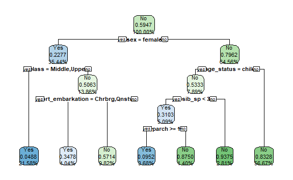

# 1.5 Question 5

Write down what this tells you, in detail. What variables are important? What does each node tell you? Who has the highest chance of surviving? Who has the lowest? Provide as much detail as you can.

## Discussion

The probability of the overall that they did no survive is 59.4%. For those who are female, they are about 35% of the overall training set population and are expected to have died 22% of the time. For the men this is higher at 80%. A male child take about 8% of the population on the ship. The chance of survival is about 90% if there are >=1 parent and less than 3 siblings. The highest proability of death is highest for a male child with 3 or more siblings. The highest chance of survival is upper class/middle class women with a 95% survival rate.

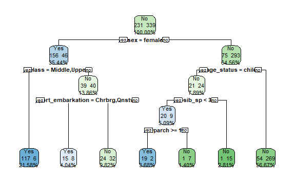

```r
titanic_train %>%
  group_by(survived_flag) %>%
  summarise(n())
```

| survived_flag | n() |
| --- | --- |
| Yes | 231 |
| No | 339 |